# Bayesian Probabilistic Selection index

José Tiago Barroso Chagas , ESALQ/USP.

Saulo Fabrício da Silva Chaves , ESALQ/USP.

Kaio Olímpio das Graças Dias , DBG/UFV.

14 November 2025

<sup>1</sup> Department of Genetics, Luiz de Queiroz College of Agriculture, University of São Paulo  
<sup>2</sup> Department of General Biology, Federal University of Viçosa

# Introduction

This workflow will help you in the Bayesian probabilistic selection index (BPSI) usage. To apply this tool for your crop, it’s recommended pay attention to each section and run carrefully the codes. Any questions? Contact us by ProbBreed or e-mail.

## Pan-African Soybean Trials dataset

Cultivar recommendation is a critical stage in plant breeding programs, and selecting superior genotypes for multiple traits remains a challenge due to the genotypes × environment (G × E) interaction.

To address this, we analyzed multi-environment trials data from Pan-African Trials, evaluating 65 soybean genotypes across 19 environments (Araújo et al. 2025).

Our methodological approach integrates Bayesian probabilistic framework to estimate genotypes risk recommendation to each trait and select genotypes according to a multitrait ideotype (Chagas et al. 2025). The Bayesian probabilistic selection index (BPSI) select the 10% genotypes with higher probability of superior performance across environments to Grain Yield (GY), Plant Height (PH) and Number of Days to Maturity (NDM).

## Bayesian probabilistic selection index (BPSI)

The Bayesian probabilistic selection index enables design ideotype by increase or decrease and weighting traits. Along with the probabilities of superior performance across environments (Dias et al. 2022). It accounts for the distance between the worst genotype performance and candidate genotypes for each trait.

$$BPSI_i = \sum_{m=1}^{t} \frac{\gamma_{pt} -\gamma_{it} }{(1/\lambda_t)}$$

where $\gamma_p$ is the probability of superior performance of the worst genotype for the trait $m$, $\gamma$ is the probability of superior performance of genotype $i$ for trait $m$, $t$ is the total number of traits evaluated, $\left(m = 1, 2, ..., t \right)$, and $\lambda$ is the weight for each trait $t$.

# BPSI example at soybean dataset

## Bayesian Model

The Bayesian model are available at ProbBreed package (Chaves et al. 2024). We used the entry mean model.

$$y_{jk} = \mu + l_k + g_j + \varepsilon_{jk}$$
where the $y_{jk}$ is the phenotypic record of the genotype $j^{th}$ in the $k^{th}$ location, $\mu$ is the intercept, $l_k$ is the main effects of the location, $g_j$ is the main effect of the genotype, and $\epsilon_{jk}$ is the residual effect.

```r
library(ProbBreed)


met_df=read.csv("https://raw.githubusercontent.com/tiagobchagas/BPSI/refs/heads/main/Data/blues_long.csv",header=T)

head(met_df)
```

```
##   env gen       PH       GY NDM
## 1 E01 G02 77.56172 3690.918  NA
## 2 E01 G05 81.16229 1004.449  NA
## 3 E01 G09 62.17745 3062.170  NA
## 4 E01 G11 33.37286 1804.674  NA
## 5 E01 G14 52.03038 2719.217  NA
## 6 E01 G21 97.85586 1747.515  NA
```

```r
mod = bayes_met(data = met_df,
                gen = "gen",
                loc = "env",
                repl = NULL,
                trait = "PH",
                reg = NULL,
                year = NULL,
                res.het = T,
                iter =400, cores = 4, chain = 4) #recommended run at least 4k iterations


mod2 = bayes_met(data = met_df,
                 gen = "gen",
                 loc = "env",
                 repl = NULL,
                 trait = "GY",
                 reg = NULL,
                 year = NULL,
                 res.het = T,
                 iter = 400, cores = 4, chain = 4) #recommended run at least 4k iterations

mod3 = bayes_met(data = met_df,
                 gen = "gen",
                 loc = "env",
                 repl =  NULL,
                 trait = "NDM",
                 reg = NULL,
                 year = NULL,
                 res.het = T,
                 iter = 400, cores = 4, chain = 4) #recommended run at least 4k iterations
```

## Extracting the probability of superior performance

```r
models=list(mod,mod2,mod3)
names(models) <- c("PH","GY","NDM")
inc=c(FALSE,TRUE,FALSE)
names(inc) <- names(models)

results <- lapply(names(models), function(model_name) {
  x <- models[[model_name]]  # actual model object

  outs <- extr_outs(model = x,
                    probs = c(0.05, 0.95),
                    verbose = TRUE)

  a <- prob_sup(extr = outs,
                int = .2,
                increase = inc[[model_name]],  # ← now model_name is a character!
                save.df = FALSE,
                verbose = TRUE)

  return(a)
})
names(results) <- names(models)
```

## Running the BPSI

```r
index=bpsi(problist=results,
          increase = c(FALSE,TRUE,FALSE),
          int = 0.1,
          lambda =c(1,2,1),
          save.df = F)
```

## BPSI Ranks

The selected genotypes (G52, G43, G26, G41, G54, G58) have superior performance for the three traits evaluated Grain Yield (GY), Plant Height (PH) and Number of Days to Maturity (NDM).

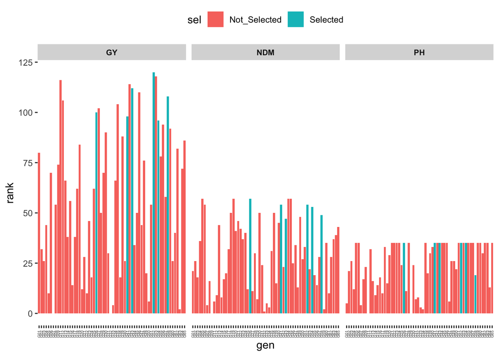

Rank of probability of superior performance of soybean Pan-African Trials across locations in Kenya

```r
plot(index,category = "Ranks")
```

## BPSI plot

The selected genotypes (G52, G43, G26, G41, G54, G58) have minor risk of cultivar recomendation to the multitrait ideotype across the Kenya environments.

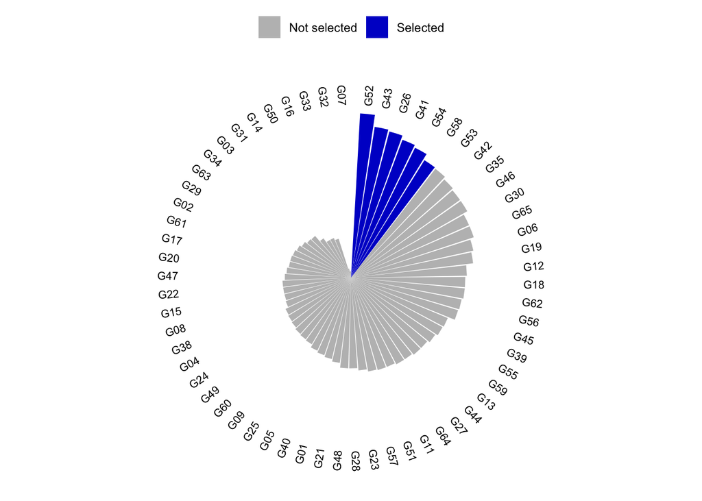

Bayesian probability selection index of soybean genotypes from Pan-African Trials across locations in Kenya

```r
plot(index,category = "BPSI")
```

## Probabilities of superior performance

The probability os superior performance across environments show the risk recommendation of the soybean genotypes being in the top 20% to Grain Yield (GY) and the bottom 20% for Plant Height (PH) and Number of Days to Maturity (NDM).

```r
df=index$df
df |> kableExtra::kable()
```

|  | PH | GY | NDM |
| --- | --- | --- | --- |
| G01 | 0.95500 | 0.20250 | 0.19750 |
| G02 | 0.05875 | 0.15625 | 0.09625 |
| G03 | 0.01000 | 0.14750 | 0.23250 |
| G04 | 0.49875 | 0.16375 | 0.03375 |
| G05 | 0.00000 | 0.13375 | 0.00000 |
| G06 | 0.00000 | 0.19000 | 0.00125 |
| G07 | 0.98375 | 0.11375 | 0.73625 |
| G08 | 0.10875 | 0.18000 | 0.29250 |
| G09 | 0.01625 | 0.19375 | 0.96250 |
| G11 | 1.00000 | 0.34625 | 0.63375 |
| G12 | 0.00500 | 0.29750 | 0.43500 |
| G13 | 0.12875 | 0.18875 | 0.01750 |
| G14 | 0.80125 | 0.15875 | 0.52375 |
| G15 | 0.39250 | 0.18250 | 0.23500 |
| G16 | 0.10250 | 0.13625 | 0.20125 |
| G17 | 0.76500 | 0.15875 | 0.06000 |
| G18 | 0.00125 | 0.18750 | 0.00375 |
| G19 | 0.17250 | 0.21500 | 0.00000 |
| G20 | 0.00750 | 0.13500 | 0.02375 |
| G21 | 0.00000 | 0.15250 | 0.01375 |
| G22 | 0.00000 | 0.13375 | 0.02250 |
| G23 | 0.00000 | 0.16750 | 0.03250 |
| G24 | 0.00000 | 0.14000 | 0.02500 |
| G25 | 0.01250 | 0.18750 | 0.35500 |
| G26 | 0.00000 | 0.28000 | 0.00000 |
| G27 | 0.54125 | 0.29000 | 0.39625 |
| G28 | 0.00000 | 0.17750 | 0.06875 |
| G29 | 1.00000 | 0.19000 | 0.59125 |
| G30 | 0.01250 | 0.22875 | 0.00375 |
| G31 | 0.93250 | 0.15500 | 0.11125 |
| G32 | 0.91875 | 0.11375 | 0.81125 |
| G33 | 0.99250 | 0.12125 | 0.68875 |
| G34 | 0.99375 | 0.18875 | 0.74500 |
| G35 | 0.00000 | 0.29375 | 0.06750 |
| G38 | 0.08875 | 0.14000 | 0.00375 |
| G39 | 0.00625 | 0.22625 | 0.30000 |
| G40 | 0.00125 | 0.14750 | 0.01625 |
| G41 | 0.00000 | 0.26000 | 0.00125 |
| G42 | 0.00000 | 0.32000 | 0.11500 |
| G43 | 0.00000 | 0.31750 | 0.01125 |
| G44 | 0.00000 | 0.15750 | 0.00000 |
| G45 | 0.00000 | 0.17750 | 0.00000 |
| G46 | 0.00000 | 0.30125 | 0.10750 |
| G47 | 0.94875 | 0.16375 | 0.04875 |
| G48 | 0.01000 | 0.20000 | 0.32250 |
| G49 | 0.01000 | 0.14250 | 0.01000 |
| G50 | 0.01750 | 0.13125 | 0.07375 |
| G51 | 0.00000 | 0.18000 | 0.05500 |
| G52 | 0.00000 | 0.43125 | 0.00125 |
| G53 | 0.00000 | 0.35375 | 0.18875 |
| G54 | 0.00000 | 0.24625 | 0.00250 |
| G55 | 0.00000 | 0.20125 | 0.23000 |
| G56 | 0.00000 | 0.24250 | 0.30625 |
| G57 | 0.00000 | 0.18500 | 0.07125 |
| G58 | 0.09375 | 0.29875 | 0.00750 |
| G59 | 0.00000 | 0.23875 | 0.78375 |
| G60 | 0.00000 | 0.14750 | 0.03875 |
| G61 | 0.00625 | 0.16125 | 0.39750 |
| G62 | 0.00000 | 0.21125 | 0.07125 |
| G63 | 0.00000 | 0.11500 | 0.03250 |
| G64 | 0.40625 | 0.19125 | 0.02625 |
| G65 | 0.00000 | 0.21625 | 0.02125 |

## Genotypes selected

The genotypes by BPSI selected were G52, G43, G26, G41, G54, G58. It have the greater distance to the worst genotype to Grain Yield (GY), Plant Height (PH) and Number of Days to Maturity (NDM). The genotype selected are the 10% multitrait top performance across enviroments.

```r
df=index$bpsi

df |> kableExtra::kable()
```

[output not shown]

## Bibliography

Araújo, Mauricio S., Saulo Chaves, Gérson N. C. Ferreira, et al. 2025. “High-Resolution Soybean Trial Data Supporting the Expansion of Agriculture in Africa.” *Scientific Data*, ahead of print. https://doi.org/10.1038/s41597-025-06190-3.

Chagas, José T. B., Kaio O. G. Dias, Vinicius Q. Carneiro, et al. 2025. “Bayesian Probabilistic Selection Index in the Selection of Common Bean Families.” *Crop Science* 65 (May): e70072. https://doi.org/10.1002/CSC2.70072.

Chaves, Saulo F. S., Matheus D. Krause, Luiz A. S. Dias, Antonio A. F. Garcia, and Kaio O. G. Dias. 2024. “ProbBreed: A Novel Tool for Calculating the Risk of Cultivar Recommendation in Multienvironment Trials.” *G3 Genes|Genomes|Genetics* 14 (March). https://doi.org/10.1093/G3JOURNAL/JKAE013.

Dias, Kaio O. G., Jhonathan P. R. dos Santos, Matheus D. Krause, et al. 2022. “Leveraging Probability Concepts for Cultivar Recommendation in Multi-Environment Trials.” *Theoretical and Applied Genetics* 135 (April): 1385–99. https://doi.org/10.1007/S00122-022-04041-Y/FIGURES/4.